# Task

12 11 2020

## YAML header

1. Add your full name and date to the RMarkdown document in the YAML header  
   -> solution see above in the header

## Plot

2. Here, add a scatter plot of the iris data set depicting Sepal.Length and Sepal.Width variables and print the figure and the code snippet.

### solution

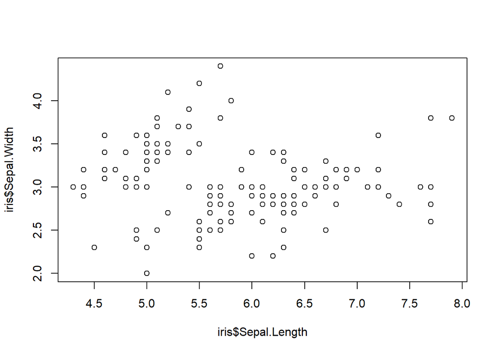

```r
plot(iris$Sepal.Length, iris$Sepal.Width)
```

## Image

3. Here, add the file git_intro/markdown_meme.jpg to the document

HINT: If this wasn’t covered in the course, just google it ;)

### solution

[figure not shown]

## Formula

4. Here, add a formula which calculates the Toxic Unit of a concentration (ci) and and EC50 value together with the corresponding text (see Markdown slides).

### solution

$$sumTU = log10 \left( \sum_{i=1}^n \frac{c_i}{EC_{50_{i}}} \right)$$

where $c_i$ is the concentration of the pesticide $i$ and $EC_{50i}$ is the concentration of pesticide $i$ at which 50 % of the test organisms (*Daphnia magna*) were affected.

## Table

5. Create a table with three columns and 4 rows.

### solution

| column 1 | column 2 | column 3 |
| --- | --- | --- |
| row 1 | row 1 | row 1 |
| row 2 | row 2 | row 2 |
| row 3 | row 3 | row 3 |
| row 4 | row 4 | row 4 |

## list

6. Create a unordered list with 3 points.

## Other

5. Add a table of contents to the document.  
   -> solution see above, toc will float
6. Add a link pointing to the GitHub repository of the course here.

### solution

Option 1: https://github.com/njuvigny/MOD3

Option 2: [MOD3 @ GitHub](https://github.com/njuvigny/MOD3)